# ESTADÍSTICA APLICADA

UNIDAD 4

**Curso de Estadística Aplicada para la EAP de Ciencia de la Computación de la Univeridad Continental**

# 🔗 Cadenas de Markov

### Proceso Estocástico

- Un `PROCESO ESTOCÁSTICO` es un modelo matemático que describe la evolución de un sistema en el tiempo cuando existe incertidumbre o aleatoriedad.
  - Definido formalmente como una **colección de variables aleatorias**
    $$\{X_t, t\in T
    \}$$
    definidas sobre un mismo espacio de probabilidad, donde: $t$ representa el tiempo (discreto o continuo), $X_t$ es el estado del sistema en el instante $t$.
  - Piensa en un proceso estocástico como una secuencia de valores que cambian con el tiempo de forma no determinista (**serie de tiempo**). No puedes predecir exactamente qué ocurrirá, pero sí puedes describirlo probabilísticamente.
- Propiedades y conceptos claves:
  - **Espacio de Estados**: valores posibles de $X_t$, discreto o continuo.
  - **Indice Temporal** valores de $t$, discreto o continuo.
  - **Dependencia Temporal** cómo influye el pasado en el futuro.
- Ejemplos relevantes en computación:
  - Cadenas de Markov: modelan navegación web (PageRank)
  - Procesos de Poisson: llegadas de solicitudes a un servidor
  - Series de tiempo (ARIMA): predicción de datos (ventas, tráfico)
  - Random walks: algoritmos probabilísticos

### Cadena de Markov en Tiempo Discreto

- *Andréi Markov* (1906) convirtió la dependencia probabilistica en estructura matemática.
- Una [CADENA DE MARKOV](https://www.youtube.com/watch?v=6pO6Mm2qJaE) en tiempo discreto (CMTD) es un proceso estocástico donde la evolución futura del sistema depende exclusivamente de su estado actual, no de su historial pasado.
  - Definido formalmente como:
    $$\{X_n \},
    n=0,1,2,...$$
    $$X_0,X_1,X_2,...$$
  - Propiedad de Markov: (memoria corta)
    $$Pr(X_{n+1}=j|X_n=i,X_{n-1}=i_{n-1},...,X_0=i_0)=Pr(X_{n+1}=j|X_n=i)$$
- Componentes:
  - **Estados**: Conjunto de posibles valores de $X_t$ (situaciones del sistema). Por ejemplo en el sistema climatico, hay estados {Soleado, Luvioso, Nublado}
  - **Matriz de Transición**: Describe las probabilidades de pasar de un estado a otro, por ejemplo para el sistema climatico.
    $$P =
    \begin{bmatrix}
    0.6 & 0.2 & 0.2 \\
    0.3 & 0.5 & 0.2 \\
    0.4 & 0.3 & 0.3
    \end{bmatrix}$$
  - Matrices Estocásticas (cada fila suma 1)

Interpretación:

| Estado actual → siguiente | Soleado (S) | Lluvioso (L) | Nublado (N) |
| --- | --- | --- | --- |
| **Soleado (S)** | 0.6 | 0.2 | 0.2 |
| **Lluvioso (L)** | 0.3 | 0.5 | 0.2 |
| **Nublado (N)** | 0.4 | 0.3 | 0.3 |

- Si hoy está Soleado:
  - 60% sigue Soleado
  - 20% pasa a Lluvioso
  - 20% pasa a Nublado
- Si hoy está Lluvioso:
  - 50% sigue Lluvioso
  - 30% pasa a Soleado
  - 20% pasa a Nublado
- Si hoy está Nublado:
  - 40% pasa a Soleado
  - 30% pasa a Lluvioso
  - 30% sigue Nublado
- **Distribución de Probabilidad**: Describe cómo se reparte la probabilidad de que el sistema esté en cada estado en un instante dado.
  - La distribución de probabilidad es un vector:
    $$\pi^{(n)}=(\pi_1^{(n)},\pi_2^{(n)},...,\pi_k^{(n)})$$
    donde $\pi_i^{(n)}=Pr(X_n=i)$, representa la probabilidad de que el sistema esté en el estado $i$ en el tiempo $n$.
  - La distribución de probabilidad cambia según la matriz de transición $P$:
    $$\pi^{(n+1)}=\pi^{(n)}P$$
    Si multiplicas la distribución actual por la matriz de transición, entonces obtienes la distribución del siguiente paso.

Por ejemplo, en el sistema climatico, supongamos que la distrubución inicial es:
$$\pi^{(0)}=(1,0,0)$$
, esta soleado, despues de un paso (una unidad de tiempo)
$$\pi^{(1)}=\pi^{(0)}P$$

$$\pi^{(1)}=(1,0,0)\begin{bmatrix}
0.6 & 0.2 & 0.2 \\
0.3 & 0.5 & 0.2 \\
0.4 & 0.3 & 0.3
\end{bmatrix} = (0.6,0.2,0.2)$$

- Propiedades: $\sum_i \pi_i^{(n)} =1$, donde $\pi_i^{(n)}\geq 0$
- **Distribución Estacionaria**: En una cadena de Markov se refiere a una situación en la que la distribución de probabilidades sobre los estados no cambia con el tiempo.

$$\pi P=\pi$$
Las probabilidades de estar en cada estado se vuelven estables Aunque el sistema siga evolucionando, la distribución ya no cambia.

Ejemplo del sistema climatico:

Interpretación:

```r
# Estados
states <- c("Soleado", "Lluvioso", "Nublado")

# Matriz de transición
P <- matrix(c(
  0.6, 0.2, 0.2,
  0.3, 0.5, 0.2,
  0.4, 0.3, 0.3
), nrow = 3, byrow = TRUE)

colnames(P) <- states
rownames(P) <- states

print("Matriz de transición:")
```

```
[1] "Matriz de transición:"
```

```r
print(P)
```

```
         Soleado Lluvioso Nublado
Soleado      0.6      0.2     0.2
Lluvioso     0.3      0.5     0.2
Nublado      0.4      0.3     0.3
```

```r
pi0 <- c(1, 0, 0)  # 100% Soleado

n_steps <- 20
distributions <- matrix(0, nrow = n_steps, ncol = 3)
distributions[1, ] <- pi0

for (t in 2:n_steps) {
  distributions[t, ] <- distributions[t-1, ] %*% P
}

colnames(distributions) <- states

matplot(distributions, type = "l", lty = 1, lwd = 2,
        xlab = "Tiempo (días)",
        ylab = "Probabilidad",
        main = "Evolución de la distribución de estados")

legend("right", legend = states, lty = 1, lwd = 2)


eig <- eigen(t(P))
stationary <- Re(eig$vectors[,1])
stationary <- stationary / sum(stationary)

print("Distribución estacionaria:")
```

```
[1] "Distribución estacionaria:"
```

```r
print(stationary)
```

```
[1] 0.4603175 0.3174603 0.2222222
```

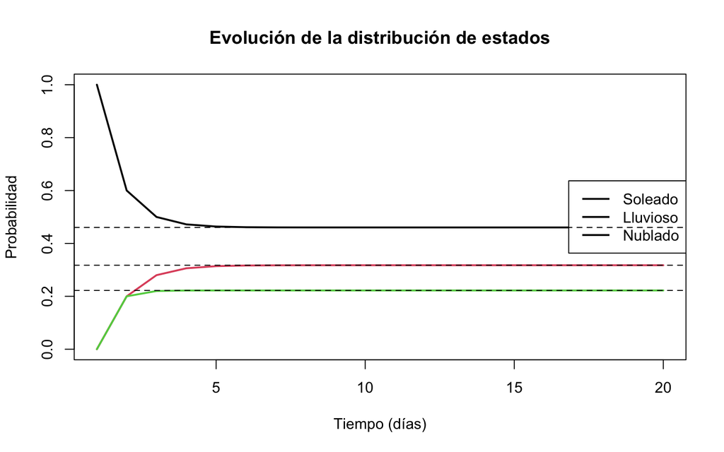

```r
abline(h = stationary, lty = 2)
```

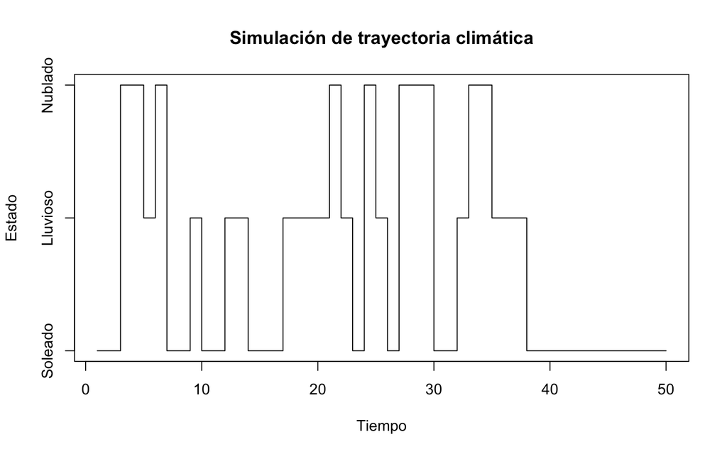

```r
set.seed(123)
n_sim <- 50
current_state <- 1
trajectory <- numeric(n_sim)
trajectory[1] <- current_state

for (t in 2:n_sim) {
  current_state <- sample(1:3, size = 1, prob = P[current_state, ])
  trajectory[t] <- current_state
}

# Convertir a nombres
trajectory_states <- states[trajectory]

# Gráfico de trayectoria
plot(trajectory, type = "s", yaxt = "n",
     xlab = "Tiempo",
     ylab = "Estado",
     main = "Simulación de trayectoria climática")

axis(2, at = 1:3, labels = states)
```

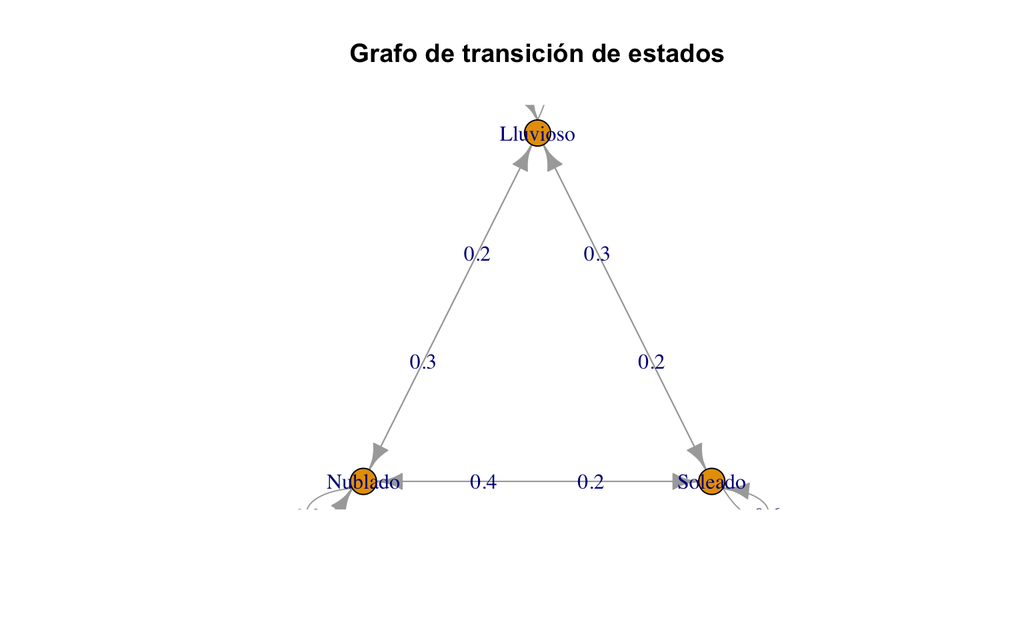

```r
if (!require(igraph)) install.packages("igraph")
library(igraph)

g <- graph_from_adjacency_matrix(P, mode = "directed", weighted = TRUE)

plot(g,
     edge.label = round(E(g)$weight, 2),
     vertex.label = states,
     main = "Grafo de transición de estados")
```

# 𓄧 Procesos de Poisson

### Propósito

- Definir un proceso de Poisson de tiempo continuo.
- Comprender las propiedades fundamentales del proceso.
- Relacionar el proceso de Poisson con la distribución exponencial.
- Modelar tiempos de espera en sistemas de colas.
- Implementar simulaciones y visualizaciones en R.

### Motivación

Muchos casos reales ocurren de manera aleatoria en el tiempo:

- Llegadas de clientes a un banco.
- Solicitudes a un servidor web.
- Llamadas telefónicas.
- Paquetes en una red.
- Vehículos llegando a un peaje.

El Proceso de Poisson es uno de los modelos más importantes para representar estos eventos aleatorios.

### Historia

- *Siméon Poisson* (1837) *Recherches sur la probabilité des jugements en matière criminelle et en matière civile*. En este trabajo estudió eventos raros (poco frecuentes), errores judiciales.
- Descubrió que cuando el número de ensayos es muy grande, la probabilidad de éxito es muy pequeña, asi planteó una nueva distribución de probabilidad (mediante convergencia de la binomial):
  $$Pr(X=k)=\frac{\lambda^k
  e^{-\lambda}}{k!}$$

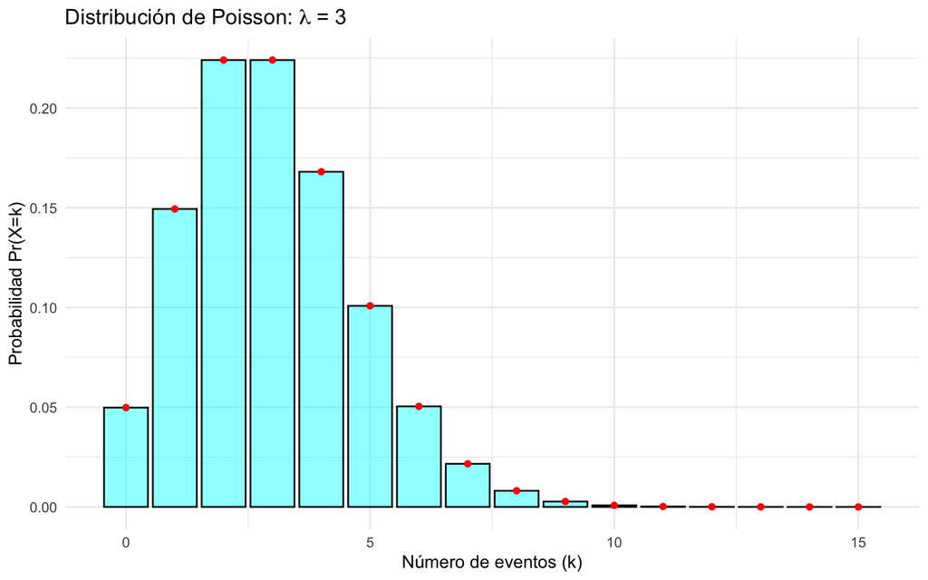

```r
library(latex2exp)
# Parámetros
lambda_val <- 3
x_vals <- 0:15

# Crear data frame
data <- data.frame(k = x_vals, prob = dpois(x_vals, lambda = lambda_val))

# Graficar
ggplot(data, aes(x = k, y = prob)) +
  geom_col(fill = "cyan", color = "black", alpha = 0.5) +
  geom_point(color = "red") +
  labs(title = TeX(paste0("Distribución de Poisson: $\\lambda$ = ", lambda_val, "$")),
       x = "Número de eventos (k)",
       y = "Probabilidad Pr(X=k)") +
  theme_minimal()
```

- Posteriormente extendieron la idea hacia los procesos estocásticos en tiempo continuo, dando origen a los procesos de Poisson.
- *Anger Erlang* (1909) `Teoría de Colas` Desarrollo modelos para calcular congestión de llamadas, tiempos de espera, para modelar llegadas de llamdas telefónicas.

### Definición del Proceso de Poisson

- Un proceso estocástico $\{N(t),t\geq0\}$ es un **Proceso de Poisson** con tasa $\lambda >0$, si:
  - $N(0)=0$: El proceso comienza sin eventos
  - Incrementos Independeintes: El número de eventos que ocurren en intervalos de tiempo disjuntos es independiente entre sí (e.g. el número de eventos entre $[t_1, t_2]$ no afecta a $[t_3, t_4]$).
  - Incrementos Estacionarios: La distribución del número de eventos en cualquier intervalo depende solo de la longitud del intervalo $[t-s]$, no de su ubicación en el tiempo.
  - Distribución de Poisson: Para cualquier intervalo de longitud $t$, el número de eventos $N(t)$ sigue una distribución de Poisson con media $\lambda t$:
    $$Pr(N(t)=k)=\frac{(\lambda t)^k e^{-\lambda
    t}}{k!}, \ \ \ k=0,1,2,\dots$$
  - Donde:
    - $\lambda$: tasa promedio de llegadas por unidad de tiempo.
    - $t$: longitud del intervalo temporal.
    - $k$: número de eventos.

### Relación con la Distribución Exponencial ❤️

- Uno de los resultados más importantes fue demostrar que:
  - Si los eventos siguen un Proceso de Poisson, los tiempos entre llegadas siguen una distribución exponencial.
  - **Distribución Exponencial**
    $$f(t)=\lambda e^{-\lambda t}, \ \ t\geq
    0$$

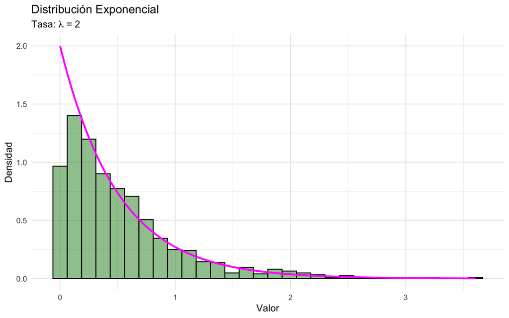

```r
set.seed(123) # Para reproducibilidad
n <- 1000
rate <- 2 # Parámetro de tasa (lambda)
data <- data.frame(value = rexp(n, rate = rate))

# Crear el gráfico con ggplot2
ggplot(data, aes(x = value)) +
  # Histograma
  geom_histogram(aes(y = ..density..), bins = 30, fill = "forestgreen", color = "black", alpha = 0.5) +
  # Curva de densidad teórica
  stat_function(fun = dexp, args = list(rate = rate), color = "magenta", size = 1) +
  # Etiquetas y títulos
  labs(title = "Distribución Exponencial",
       subtitle = TeX(paste0("Tasa: $\\lambda$ = ", rate, "$")),
       x = "Valor",
       y = "Densidad") +
  theme_minimal()
```

- Distribución Acumulada: $Pr(T\leq t)=1-e^{-\lambda t}$
- **En general**: Los tiempos que transcurren entre dos eventos consecutivos $T_{n}$ son variables aleatorias independientes e idénticamente distribuidas (i.i.d.) con una distribución exponencial de parámetro $\lambda$, e.i. $T_n \sim \text{Exp}(\lambda)$
- **Propiedad de Falta de Memoria** (El sistema “olvida” cuánto tiempo ya esperó.): La distribución exponencial posee la propiedad: $Pr(T>s+t|T>s)=Pr(T>t)$

### Aplicación: Sistema de Colas

Supongamos:

- Los clientes llegan al banco aleatoriamente.
- En promedio llegan 6 clientes por hora.
- Entonces: la tasa de llegadas $\lambda=6$

**Este ejemplo simula**:

- Llegadas de clientes.
- Tiempos entre llegadas.
- Tiempo de espera en cola.
- Atención por un solo cajero.

```r
set.seed(123)

# Parámetros
lambda <- 6        # llegadas por hora
mu <- 8            # clientes atendidos por hora
n <- 100           # número de clientes

# -----------------------------
# TIEMPOS ENTRE LLEGADAS
# -----------------------------
inter_arrivals <- rexp(n, rate = lambda)

# Tiempo acumulado de llegada
arrival_times <- cumsum(inter_arrivals)

# -----------------------------
# TIEMPOS DE SERVICIO
# -----------------------------
service_times <- rexp(n, rate = mu)

# -----------------------------
# SIMULACIÓN DE COLA
# -----------------------------
start_service <- numeric(n)
departure_times <- numeric(n)
waiting_times <- numeric(n)

# Primer cliente
start_service[1] <- arrival_times[1]
departure_times[1] <- start_service[1] + service_times[1]
waiting_times[1] <- 0

# Resto de clientes
for(i in 2:n){

  start_service[i] <- max(arrival_times[i],
                          departure_times[i-1])

  waiting_times[i] <- start_service[i] -
                      arrival_times[i]

  departure_times[i] <- start_service[i] +
                        service_times[i]
}

# -----------------------------
# DATA FRAME
# -----------------------------
bank_queue <- data.frame(
  Cliente = 1:n,
  Llegada = arrival_times,
  Servicio = service_times,
  Espera = waiting_times,
  Salida = departure_times
)

head(bank_queue)
```

```
  Cliente   Llegada    Servicio    Espera    Salida
1       1 0.1405762 0.057902453 0.0000000 0.1984787
2       2 0.2366779 0.029504468 0.0000000 0.2661824
3       3 0.4581871 0.147762428 0.0000000 0.6059495
4       4 0.4634500 0.007458921 0.1424995 0.6134084
5       5 0.4728185 0.050404805 0.1405900 0.6638132
6       6 0.5255687 0.117867480 0.1382446 0.7816807
```

- **Visualización de llegadas** (Proceso de Poisson)

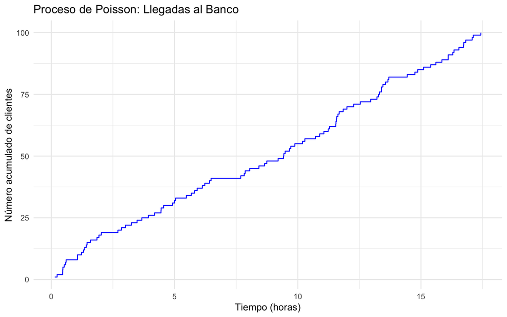

```r
ggplot(bank_queue,
       aes(x = Llegada,
           y = Cliente)) +
  geom_step(color = "blue") +
  labs(
    title = "Proceso de Poisson: Llegadas al Banco",
    x = "Tiempo (horas)",
    y = "Número acumulado de clientes"
  ) +
  theme_minimal()
```

Interpretación:

- Cada salto representa una llegada.
- Las llegadas ocurren aleatoriamente.
- El patrón escalonado es típico de un proceso de Poisson.
- **Distribución de tiempos entre llegadas**

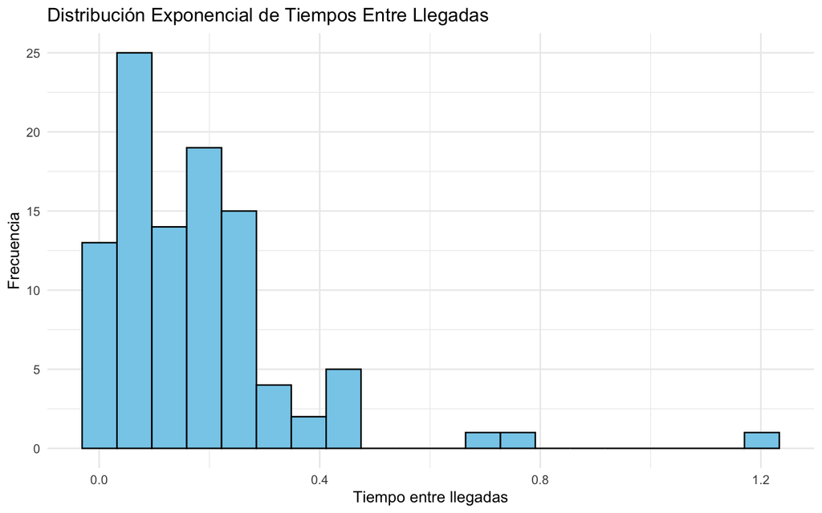

```r
ggplot(bank_queue,
       aes(x = diff(c(0, Llegada)))) +
  geom_histogram(
    bins = 20,
    fill = "skyblue",
    color = "black"
  ) +
  labs(
    title = "Distribución Exponencial de Tiempos Entre Llegadas",
    x = "Tiempo entre llegadas",
    y = "Frecuencia"
  ) +
  theme_minimal()
```

Interpretación: - Muchos clientes llegan rápidamente. - Algunos tardan más. - La distribución es asimétrica hacia la derecha.

- **Tiempo de espera en cola**

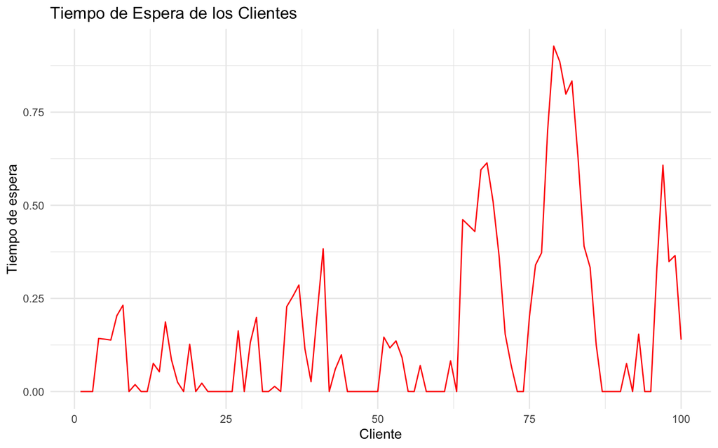

```r
ggplot(bank_queue,
       aes(x = Cliente,
           y = Espera)) +
  geom_line(color = "red") +
  labs(
    title = "Tiempo de Espera de los Clientes",
    x = "Cliente",
    y = "Tiempo de espera"
  ) +
  theme_minimal()
```

Interpretación: - Cuando llegan muchos clientes juntos, la cola crece. - Si el cajero atiende rápido, la espera disminuye.

- **Métricas importantes**

```r
cat("Tiempo promedio de espera:",
    mean(waiting_times), "\n")
```

```
Tiempo promedio de espera: 0.1646213
```

```r
cat("Máximo tiempo de espera:",
    max(waiting_times), "\n")
```

```
Máximo tiempo de espera: 0.9272724
```

```r
cat("Clientes que esperaron:",
    sum(waiting_times > 0), "\n")
```

```
Clientes que esperaron: 61
```

- **Interpretación Teórica**

En teoría de colas, este modelo corresponde a: $M/M/1$, donde:

- Primer $M$: llegadas Poisson.
- Segundo $M$: tiempo de servicios exponenciales.
- $1$: un servidor (cajero).

Condición de estabilidad: El sistema funciona bien si:

$\rho=\frac{\lambda}{\mu}<1$

Donde:

- $\lambda$: tasa de llegada.
- $\mu$: tasa de servicio.
- $\rho$: utilización del sistema.

$\rho=\frac{6}{8}=0.75$ (El cajero está ocupado el 75% del tiempo.)

### Otros Ejemplos

- `Escenario`
- Un cajero automático recibe clientes a razón de: $\lambda=5$ clientes por minuto.
- Preguntas:
  - ¿Cuántos clientes llegan en 2 minutos?
  - ¿Cuánto tiempo tarda en llegar el siguiente cliente?
  - ¿Cómo simular el sistema?
- Simulación de número de llegadas

```r
# Parámetros
lambda <- 5
t <- 2

# Simulación de llegadas
set.seed(123)

clientes <- rpois(1000, lambda * t)

# Resumen
summary(clientes)
```

```
   Min. 1st Qu.  Median    Mean 3rd Qu.    Max.
  2.000   8.000  10.000   9.983  12.000  21.000
```

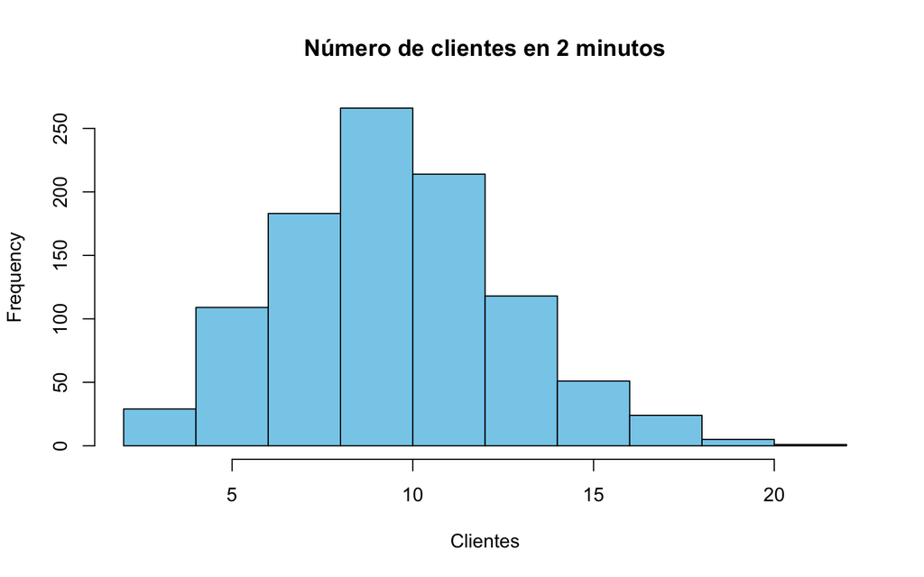

```r
# Histograma
hist(clientes,
     main="Número de clientes en 2 minutos",
     xlab="Clientes",
     col="skyblue")
```

- Simulación de Tiempos Entre Llegadas

```r
# Tiempos entre llegadas
tiempos <- rexp(1000, rate=lambda)

# Resumen
summary(tiempos)
```

```
     Min.   1st Qu.    Median      Mean   3rd Qu.      Max.
0.0001219 0.0556683 0.1333513 0.1960094 0.2746500 1.8162780
```

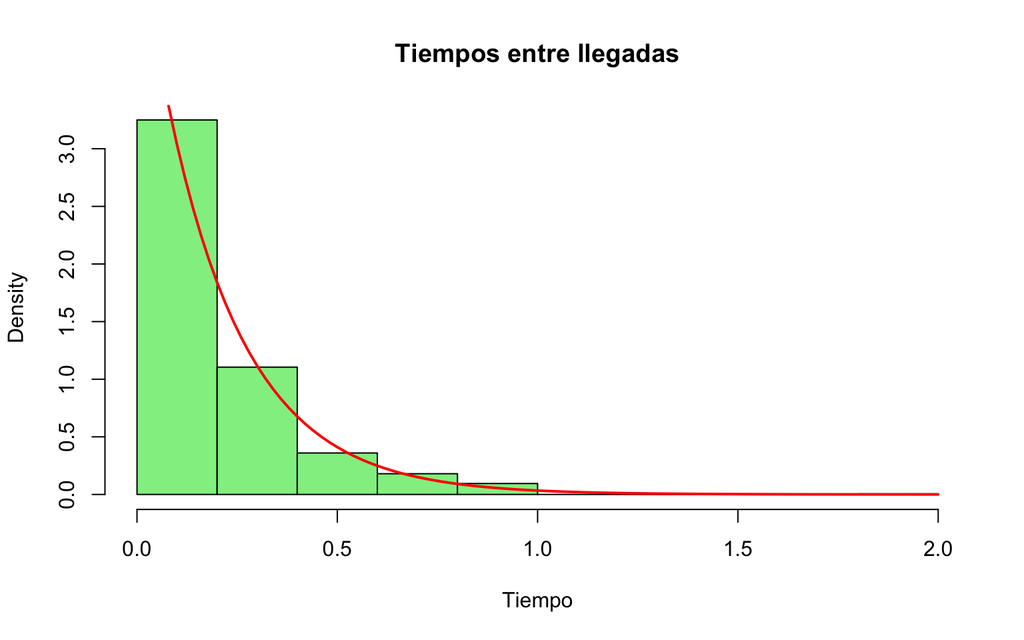

```r
# Histograma
hist(tiempos,
     probability=TRUE,
     main="Tiempos entre llegadas",
     xlab="Tiempo",
     col="lightgreen")

# Curva teórica
curve(dexp(x, rate=lambda),
      add=TRUE,
      lwd=2,
      col="red")
```

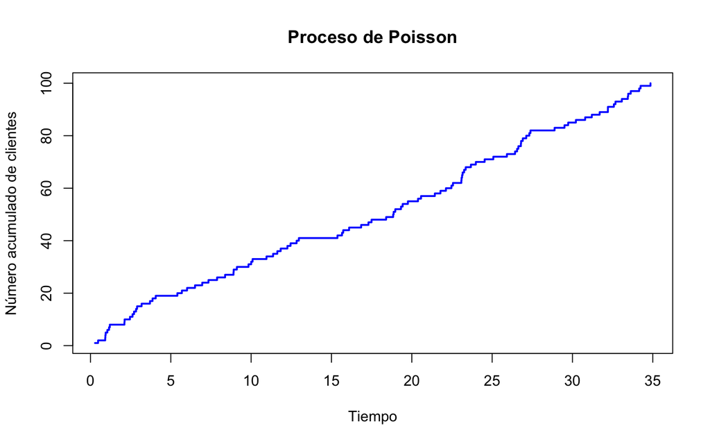

```r
set.seed(123)

# Parámetros
lambda <- 3
n <- 100

# Tiempos entre llegadas
interarrivals <- rexp(n, rate=lambda)

# Tiempos de llegada acumulados
arrival_times <- cumsum(interarrivals)

# Visualización
plot(arrival_times,
     1:n,
     type="s",
     main="Proceso de Poisson",
     xlab="Tiempo",
     ylab="Número acumulado de clientes",
     col="blue",
     lwd=2)
```

- EJEMPLO 2

```r
set.seed(123)

lambda <- 5
tiempo <- 20

eventos <- rpois(tiempo, lambda)

datos <- data.frame(
  minuto = 1:tiempo,
  llegadas = eventos
)

head(datos)
```

```
  minuto llegadas
1      1        4
2      2        7
3      3        4
4      4        8
5      5        9
6      6        2
```

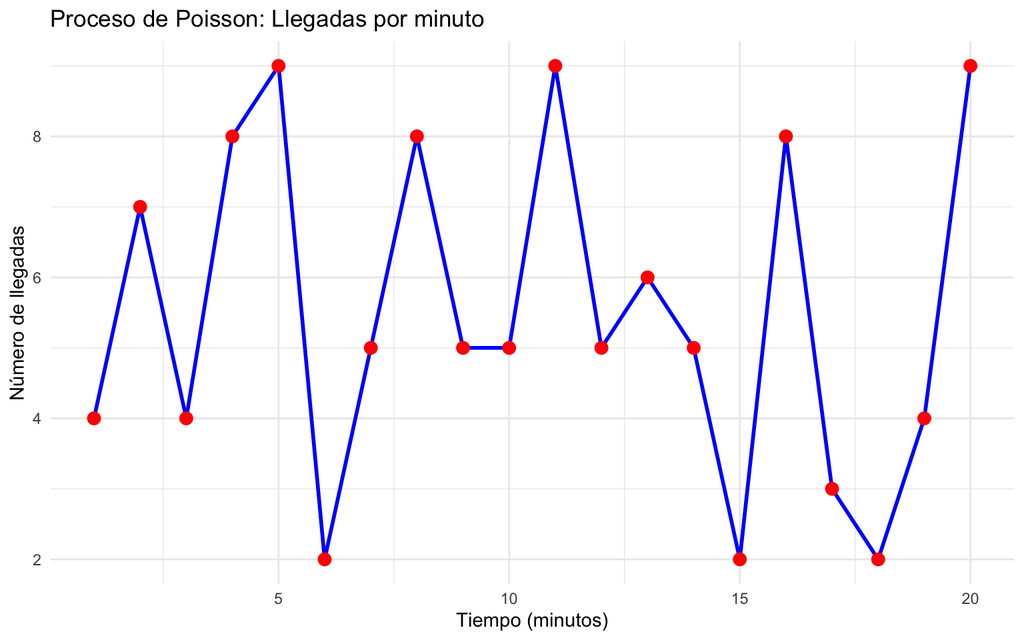

```r
ggplot(datos, aes(x = minuto, y = llegadas)) +
  geom_line(color = "blue", linewidth = 1) +
  geom_point(size = 3, color = "red") +
  labs(
    title = "Proceso de Poisson: Llegadas por minuto",
    x = "Tiempo (minutos)",
    y = "Número de llegadas"
  ) +
  theme_minimal()
```

Interpretación

- Cada punto representa clientes por minuto.
- La variabilidad es aleatoria.
- El promedio tiende a acercarse a $\lambda$
- Simulación de Tiempos Entre Llegadas

```r
set.seed(123)

lambda <- 5

tiempos_espera <- rexp(1000, rate = lambda)

datos_exp <- data.frame(
  espera = tiempos_espera
)
```

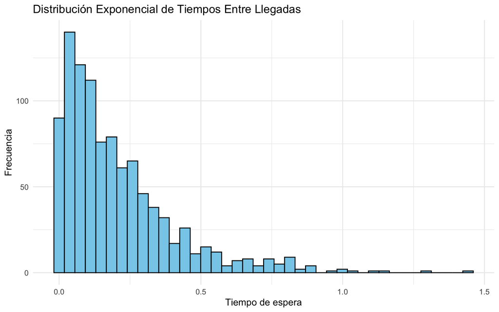

```r
ggplot(datos_exp, aes(x = espera)) +
  geom_histogram(
    bins = 40,
    fill = "skyblue",
    color = "black"
  ) +
  labs(
    title = "Distribución Exponencial de Tiempos Entre Llegadas",
    x = "Tiempo de espera",
    y = "Frecuencia"
  ) +
  theme_minimal()
```

- Simulación de una Cola Simple
- Escenario: Una ventanilla de atención:
  - Llegadas Poisson.
  - Tiempo de servicio constante.

```r
set.seed(123)

# Parámetros
lambda <- 4
n_clientes <- 100

# Tiempos entre llegadas
interarrivals <- rexp(n_clientes, rate = lambda)

# Tiempos de llegada acumulados
arrival_times <- cumsum(interarrivals)

# Tiempo de servicio
service_time <- 0.15

# Inicialización
start_service <- numeric(n_clientes)
end_service <- numeric(n_clientes)
waiting_time <- numeric(n_clientes)

# Primer cliente
start_service[1] <- arrival_times[1]
end_service[1] <- start_service[1] + service_time

# Simulación de la cola
for(i in 2:n_clientes){

  start_service[i] <- max(
    arrival_times[i],
    end_service[i-1]
  )

  end_service[i] <- start_service[i] + service_time

  waiting_time[i] <- start_service[i] - arrival_times[i]
}

# DataFrame
cola <- data.frame(
  cliente = 1:n_clientes,
  llegada = arrival_times,
  espera = waiting_time
)

head(cola)
```

```
  cliente   llegada      espera
1       1 0.2108643 0.000000000
2       2 0.3550169 0.005847432
3       3 0.6872806 0.000000000
4       4 0.6951749 0.142105660
5       5 0.7092277 0.278052916
6       6 0.7883530 0.348927612
```

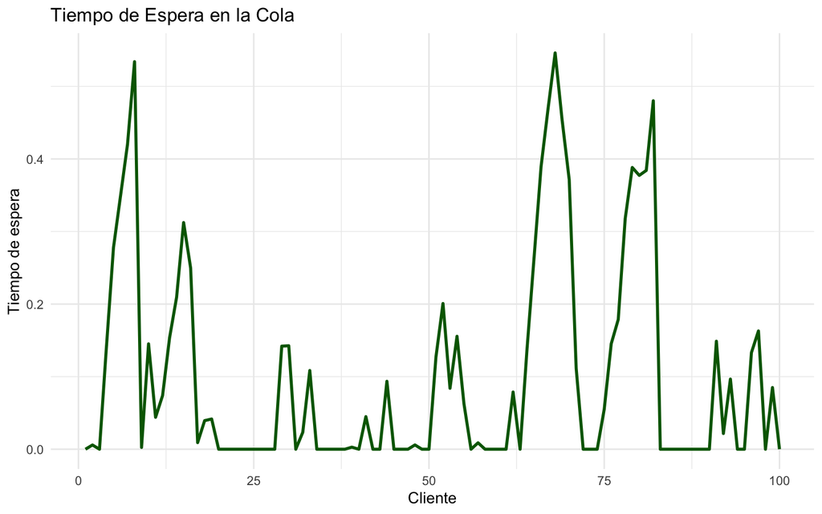

```r
ggplot(cola, aes(x = cliente, y = espera)) +
  geom_line(color = "darkgreen", linewidth = 1) +
  labs(
    title = "Tiempo de Espera en la Cola",
    x = "Cliente",
    y = "Tiempo de espera"
  ) +
  theme_minimal()
```

EN GENERAL

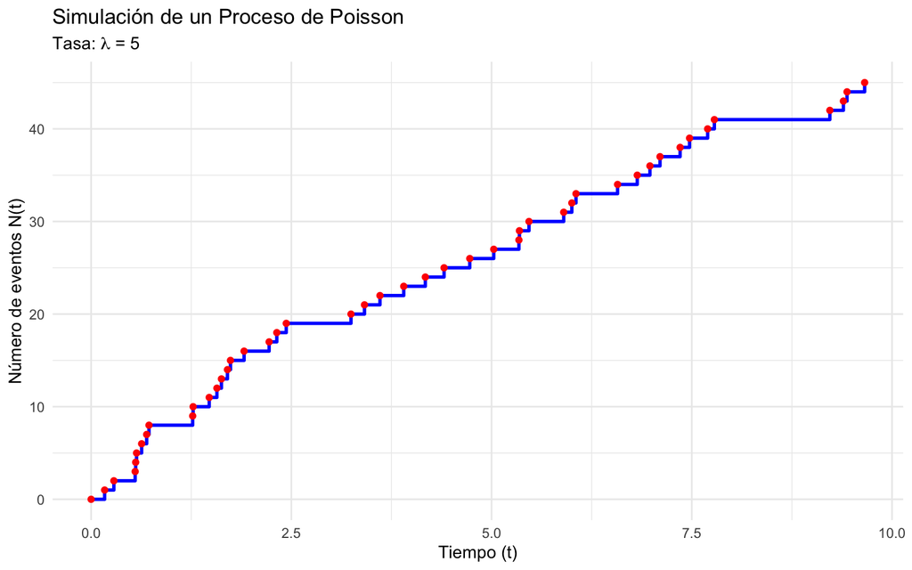

```r
set.seed(123)
# 2. Parámetros de la simulación
lambda <- 5       # Tasa promedio de eventos por unidad de tiempo
t_max <- 10       # Tiempo total de observación

# 3. Simular el Proceso de Poisson
# Tiempos entre eventos (exponenciales)
tiempos_entre <- rexp(n = t_max * lambda * 2, rate = lambda)
tiempos_llegada <- cumsum(tiempos_entre)
# Filtrar para no superar t_max
tiempos_llegada <- tiempos_llegada[tiempos_llegada <= t_max]

# Crear el número de eventos en cada tiempo
n_eventos <- 1:length(tiempos_llegada)

# Crear data frame para ggplot
df <- data.frame(
  tiempo = c(0, tiempos_llegada),
  conteo = c(0, n_eventos)
)

# 4. Graficar con ggplot2
ggplot(df, aes(x = tiempo, y = conteo)) +
  geom_step(color = "blue", size = 1) + # geom_step es clave para procesos de conteo
  geom_point(color = "red") +           # Puntos en cada evento
  labs(title = "Simulación de un Proceso de Poisson",
       subtitle = TeX(paste0("Tasa: $\\lambda$ = ", lambda, "$")),
       x = "Tiempo (t)",
       y = "Número de eventos N(t)") +
  theme_minimal()
```

# 🇵🇪 Datos Perú

- https://estadisticas.bcrp.gob.pe/estadisticas/series/
- https://www.inei.gob.pe/estadisticas-indice-tematico/
- https://systems.inei.gob.pe/SIRTOD/